# Tutorial Projecting Species Distributions

Author

Teja Kattenborn (teja.kattenborn@geosense.uni-freiburg.de); Joachim Maack (joachim.maack@geosense.uni-freiburg.de)

Published

January 21, 2025

# Simulating tree species distributions against climate change scenarios

Forest management requires decisions with long-term implications. In a changing world, we have to consider how future changes in environmental properties will affect our forests. One important question is, which tree species are appropriate under given site conditions and future changes. We will hence use machine learning models (random forest) to project the most suitable tree species for a given time and location:

These future climate scenarios are obtained from [WorldClim](https://www.worldclim.org/data/cmip6/cmip6climate.html), future climate projections are based on General Circulation Models (GCMs), which simulate climate processes using historical and current climate

The first step is to identify, collect and prepare some influential variables (like in the last week)

Set working directory

Loading the raster files and start exploring the data with some plotting

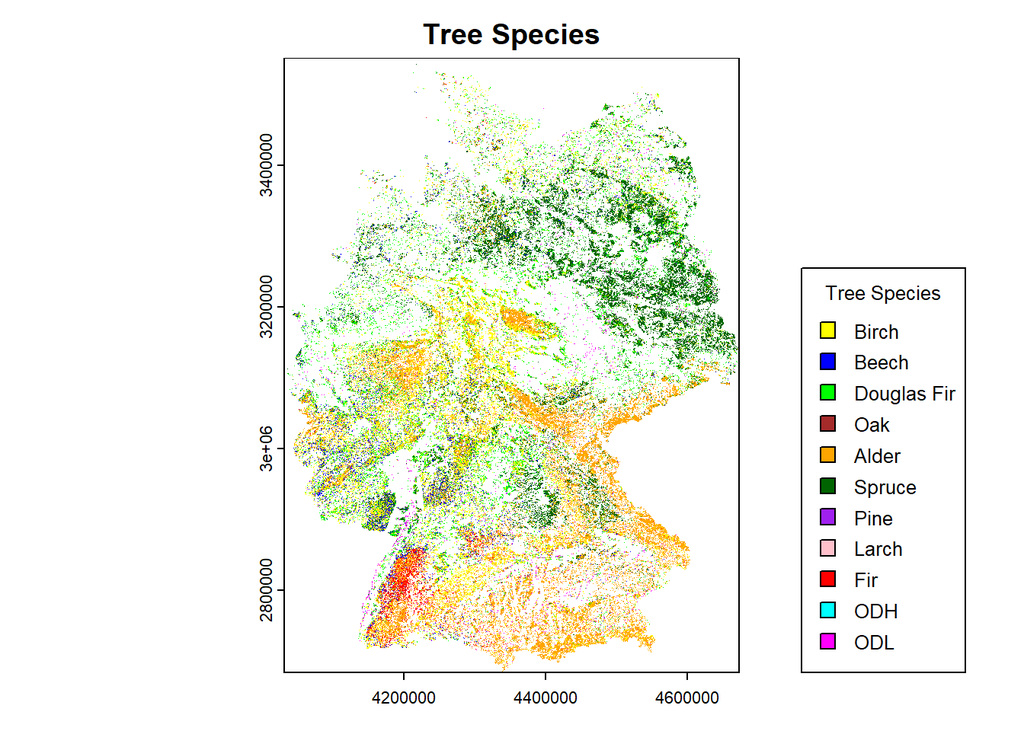

- [SRTM](https://www.earthdata.nasa.gov/data/instruments/srtm) (NASA space shuttle topography mission)
- [Worldclim](https://www.worldclim.org/data/index.html)
- [SoilGrids](https://soilgrids.org/)

What will we do?

### 1. Prepare Your Data

### 2. Sample predictor and response values

```r
# combine predictors (environmental variables) and response (tree mortality)
stack_updated = c(preds_raster_stack)

# Extract values for the response (tree mortality)
set.seed(42)
sampled_values = spatSample(stack_updated, size = 2000, method = "random", xy = TRUE, na.rm=TRUE)
nrow(sampled_values)
```

```
[1] 1949
```

```r
sampled_values$species_class_sum = as.factor(sampled_values$species_class_sum) #use this variable as a class
# Check the sampled values
head(sampled_values)
```

```
        x       y wc2.1_30s_bio_1 wc2.1_30s_bio_12 wc2.1_30s_bio_15
1 4249266 2916430        9.351789         956.0207         14.83053
2 4599466 3334830        8.617581         524.2516         25.43239
3 4501866 3036430        5.106870         935.3655         18.93643
4 4406166 2808730        8.102858         861.1170         29.83681
5 4197166 2765130        6.185803        1187.2266         14.36141
6 4464066 2887230        8.236206         692.3408         23.53127
  wc2.1_30s_bio_17 wc2.1_30s_bio_7 sand_100-200cm_mean     slope
1        212.99664        25.47134            215.6873  4.720386
2         96.95466        26.40887            589.2689  4.906311
3        192.20744        23.43409            500.0538  7.646969
4        145.15697        26.82508            365.0114  4.888646
5        256.14984        25.41114            301.9183 18.955265
6        131.07027        26.96822            314.2948  9.238043
  species_class_sum
1                 3
2                 9
3                 8
4                16
5                 8
6                 3
```

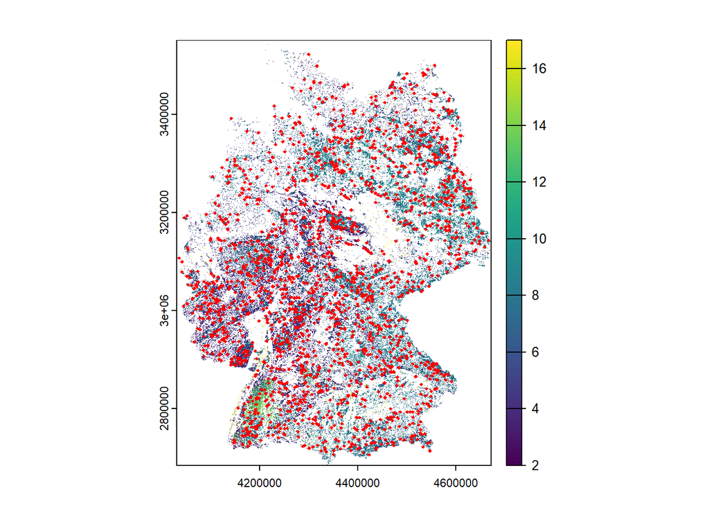

```r
plot(tree_species_map)
points(sampled_values$x, sampled_values$y, col = "red", pch = 18, cex = 0.5)
```

### 3. Train a Random Forest Model

What is a [RandomForest](https://en.wikipedia.org/wiki/Random_forest#:~:text=Random%20forests%20are%20a%20way,performance%20in%20the%20final%20model.)? RandomForest is a machine learning model. Its underlying principle is simple; it builds on decision trees. Each branch of a tree is a decision based on a predictor (e.g. a temperature value from WorldClim or Slope from SRTM). After one branch follows another branch with a subsequent decision. The special thing about randomForest is that it creates hundreds of such trees, selects the best ones and averages there result. This “democratic” majority vote makes this method so robust and its simplicity makes it so efficient. This is why for years, randomForest is one of the most effective machine learning methods for tabular data.

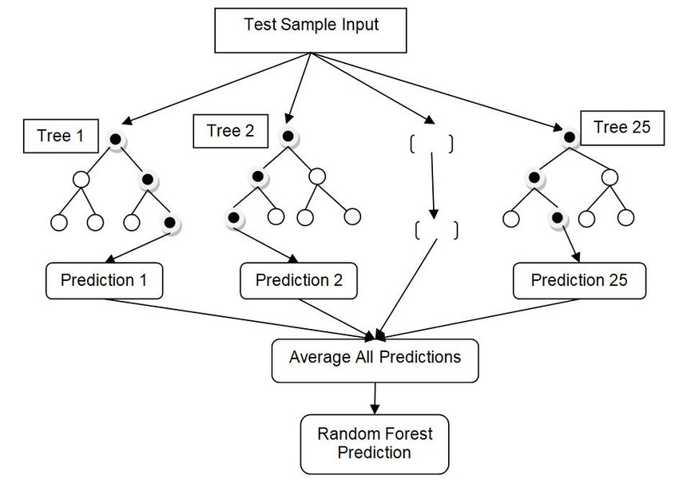

Lets train a randomForest. We will train the model a few times and check if the results (explained variance, importance of the predictors) change. Why may this happen? What influence has the sample size? You could also check the correlation between the predictors and remove one if the it exceeds 0.7.

```r
# Define the response variable (tree mortality) and predictors (climate data)
response = sampled_values$species_class_sum

# remove uncessesary variables (e.g. the x and y location)
head(sampled_values[, -c(1,2,10)])
```

```
  wc2.1_30s_bio_1 wc2.1_30s_bio_12 wc2.1_30s_bio_15 wc2.1_30s_bio_17
1        9.351789         956.0207         14.83053        212.99664
2        8.617581         524.2516         25.43239         96.95466
3        5.106870         935.3655         18.93643        192.20744
4        8.102858         861.1170         29.83681        145.15697
5        6.185803        1187.2266         14.36141        256.14984
6        8.236206         692.3408         23.53127        131.07027
  wc2.1_30s_bio_7 sand_100-200cm_mean     slope
1        25.47134            215.6873  4.720386
2        26.40887            589.2689  4.906311
3        23.43409            500.0538  7.646969
4        26.82508            365.0114  4.888646
5        25.41114            301.9183 18.955265
6        26.96822            314.2948  9.238043
```

```r
predictors = sampled_values[, -c(1,2,10)]  # All columns except the first one (response variable)

# Train the Random Forest model
# What does the argument ntree? Read the help.

rf_model = randomForest(x = predictors, y = response, importance = TRUE, ntree = 500)

# Check the model results
print(rf_model)
```

```
Call:
 randomForest(x = predictors, y = response, ntree = 500, importance = TRUE)
               Type of random forest: classification
                     Number of trees: 500
No. of variables tried at each split: 2

        OOB estimate of  error rate: 47.36%
Confusion matrix:
   2   3 4  5 6   8   9 10 14 16 17 class.error
2  0  18 3 10 1  14  30  1  0  0  0   1.0000000
3  1 263 5 31 4  86  18  5 11  0  0   0.3797170
4  2  55 1 18 1  24  11  2  0  0  0   0.9912281
5  1  66 7 70 0  21  59  5  0  0  0   0.6943231
6  0   6 1  2 0   8  23  2  0  0  0   1.0000000
8  2  78 3 10 0 410  20  0  8  0  0   0.2278719
9  4  24 3 25 1  29 275  7  0  0  0   0.2527174
10 0  28 4 13 2  12  25  1  0  0  0   0.9882353
14 0  12 0  2 0  22   0  0  6  0  0   0.8571429
16 0   9 0  1 0   9   5  1  0  0  0   1.0000000
17 0   0 0  2 0   2   8  0  0  0  0   1.0000000
```

### 4. Permutation Test

During the calculation of variable importance, the values of a predictor variable are permuted (shuffled randomly) across all observations, breaking the relationship between the predictor and the response.

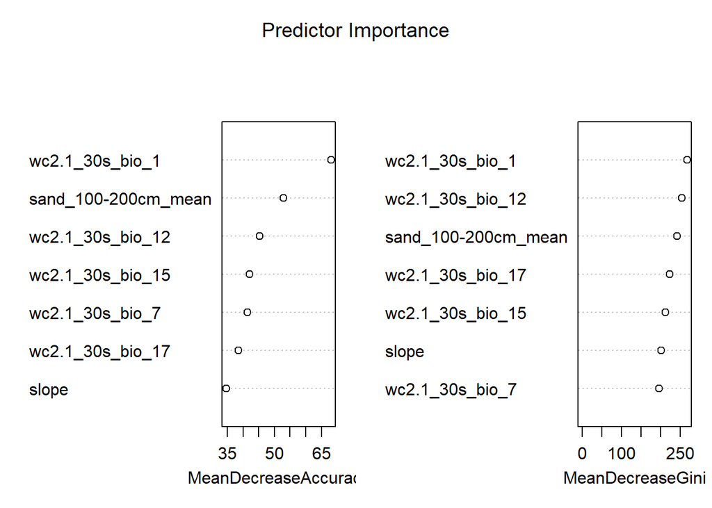

```r
varImpPlot(rf_model , sort = TRUE  , main = "Predictor Importance" )
```

You could also check the correlation between the predictors and remove one if the it exceeds +-0.7.

Further details on the WorldClim data (bio_.*) is available [here](https://www.worldclim.org/data/bioclim.html).

```r
#library(ggcorrplot)

# Visualize the correlation matrix

head(sampled_values[, -c(1,2,10)])
```

```
  wc2.1_30s_bio_1 wc2.1_30s_bio_12 wc2.1_30s_bio_15 wc2.1_30s_bio_17
1        9.351789         956.0207         14.83053        212.99664
2        8.617581         524.2516         25.43239         96.95466
3        5.106870         935.3655         18.93643        192.20744
4        8.102858         861.1170         29.83681        145.15697
5        6.185803        1187.2266         14.36141        256.14984
6        8.236206         692.3408         23.53127        131.07027
  wc2.1_30s_bio_7 sand_100-200cm_mean     slope
1        25.47134            215.6873  4.720386
2        26.40887            589.2689  4.906311
3        23.43409            500.0538  7.646969
4        26.82508            365.0114  4.888646
5        25.41114            301.9183 18.955265
6        26.96822            314.2948  9.238043
```

```r
predictors = sampled_values[, -c(1,2,10)]  # All columns except the first one (response variable)

cor_matrix = cor(predictors, use = "complete.obs")
cor_matrix
```

```
                    wc2.1_30s_bio_1 wc2.1_30s_bio_12 wc2.1_30s_bio_15
wc2.1_30s_bio_1          1.00000000       -0.6318546      -0.12631155
wc2.1_30s_bio_12        -0.63185455        1.0000000      -0.01449730
wc2.1_30s_bio_15        -0.12631155       -0.0144973       1.00000000
wc2.1_30s_bio_17        -0.57723809        0.9549182      -0.28631962
wc2.1_30s_bio_7          0.06749827       -0.2356174       0.45105786
sand_100-200cm_mean      0.25755163       -0.4325766       0.29189635
slope                   -0.39517102        0.5133954      -0.08222209
                    wc2.1_30s_bio_17 wc2.1_30s_bio_7 sand_100-200cm_mean
wc2.1_30s_bio_1           -0.5772381      0.06749827           0.2575516
wc2.1_30s_bio_12           0.9549182     -0.23561741          -0.4325766
wc2.1_30s_bio_15          -0.2863196      0.45105786           0.2918964
wc2.1_30s_bio_17           1.0000000     -0.32368431          -0.4946839
wc2.1_30s_bio_7           -0.3236843      1.00000000           0.0362305
sand_100-200cm_mean       -0.4946839      0.03623050           1.0000000
slope                      0.5137435     -0.12854788          -0.4104876
                          slope
wc2.1_30s_bio_1     -0.39517102
wc2.1_30s_bio_12     0.51339535
wc2.1_30s_bio_15    -0.08222209
wc2.1_30s_bio_17     0.51374352
wc2.1_30s_bio_7     -0.12854788
sand_100-200cm_mean -0.41048762
slope                1.00000000
```

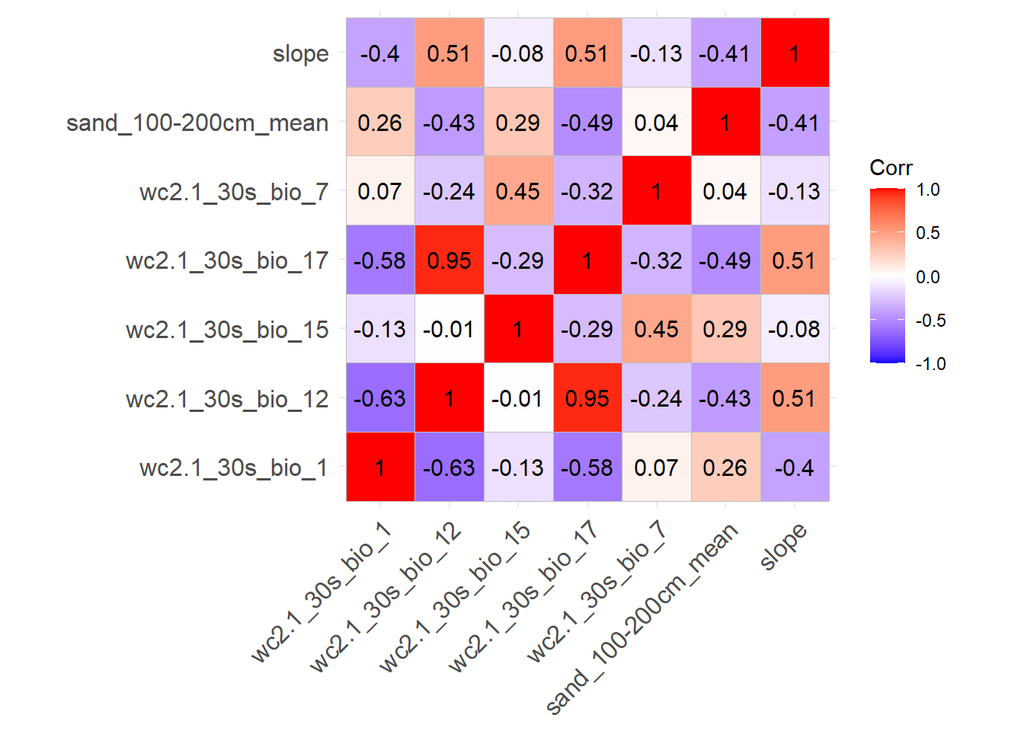

```r
ggcorrplot(cor_matrix, lab = TRUE)
```

### 5. Predict future states (optional)

**The following steps will take some time for processing. However, we have pre-processed the model results. Thus, you can skip 5. and move on to 6.**

Our model is now trained with actual data. In the following we will load possible future states of our predictor variables and present them to your model. Only the climate variables will change for this model, the soil and topographic variables will stay the same.

#### (optional) Load new data for extrapolation

```r
# Specify the folder containing the raster files of the predictors
folder_preds = "extrapol_2040_ssp2"

# List all raster files of the predictors in the folder (e.g., .tif files)
raster_files_ex = list.files(folder_preds, pattern = "\\.tif$", full.names = TRUE)

# Load and stack the rasters
raster_stack_ex = rast(raster_files_ex)
```

```r
# Load necessary library
library(randomForest)

# Assume you have a trained Random Forest model
# rf_model = randomForest(dependent_variable ~ ., data = training_data)

# New dataset for prediction
new_data = raster_stack_ex

# Ensure the new data has the same structure as the training data
# Check the column names and factor levels if applicable
names(new_data)
names(predictors)

names(new_data) = names(predictors)

new_data = classify(new_data, rcl = cbind(NA, 0)) #RandomForest cant handle NA values

# Make predictions on the new data
predictions = terra::predict(model=rf_model, object=new_data, parallel = TRUE, type = "class")

# Load your raster (replace 'your_raster.tif' with your file)
r = predictions

# Check the categories of the first band
categories = levels(r)[[1]]


# Convert the band to integer values representing the original categories
r_int = classify(r, data.frame(ID = categories$value, Value = as.numeric(as.character(categories$class))))

# Save the resulting raster
writeRaster(r_int, "predicted_output_2400_species_ssp5.tif", overwrite = TRUE)
```

### 6. Analyzing the results

#### Plotting raster of the time steps

Now we will analyze the results of the predictions. The predictions are based on the HadGEM3-GC31 model using two different [SSP](https://de.wikipedia.org/wiki/Shared_Socioeconomic_Pathway) (Shared Socioeconomic Pathway). HadGEM3 simulates how the Earth’s climate behaves under different scenarios. It helps predict how things like temperature, rainfall, and sea levels might change in the future, based on various factors like greenhouse gas emissions. We used HadGEM3 predictions on SSP2 and SSP5.

- SSP2 is known as the “middle of the road” scenario. It represents a future where global development follows a moderate path with no major disruptions or significant shifts in either direction.
- SSP5 represents a scenario where the world continues a high-emission, fossil-fuel-driven economic development, with significant technological advancements but also with rising challenges in terms of environmental degradation.

We pre-processed raster files using both scenarios for the years 2040, 2060, 2080 and 2100.

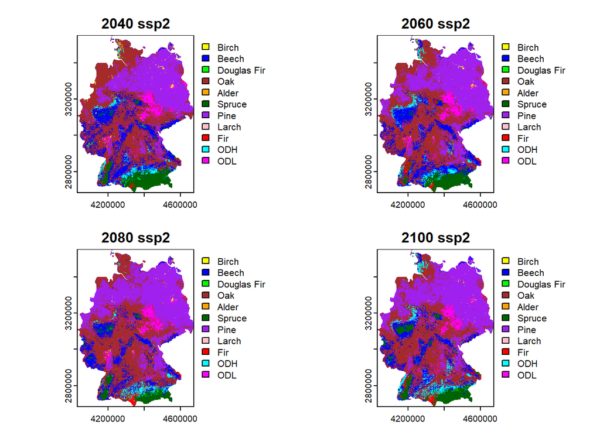

```r
# Load german vector data for masking
germany = ne_countries(country = "Germany", scale = "medium", returnclass = "sf")
# Convert to SpatVector (terra format)
germany_terra = vect(germany)
germany_terra = project(germany_terra, "EPSG:3035")

# Specify the folder containing the raster files of the predictors
folder_preds = "Predictions_tree_species"

# List all raster files of the predictors in the folder (e.g., .tif files)
raster_files_preds = list.files(folder_preds, pattern = "\\.tif$", full.names = TRUE)

# Load and stack the rasters
raster_stack_preds = as.factor(rast(raster_files_preds))
raster_stack_preds = mask(raster_stack_preds, germany_terra)


# Assign species names to the raster categories
for (i in 1:nlyr(raster_stack_preds)) {
  levels(raster_stack_preds[[i]]) <- data.frame(
    ID = as.numeric(names(species_labels)),  # Integer codes
    Class = species_labels                  # Species names
  )
}

# User-defined titles for the plots
titles_ssp2 = c("2040 ssp2", "2060 ssp2", "2080 ssp2", "2100 ssp2")
titles_ssp5 = c("2040 ssp5", "2060 ssp5", "2080 ssp5", "2100 ssp5")

# Plot with proper legend and species names for ssp2
plot(raster_stack_preds[[c(1,3,5,7)]],
     main = titles_ssp2,
     col = species_colors)
```

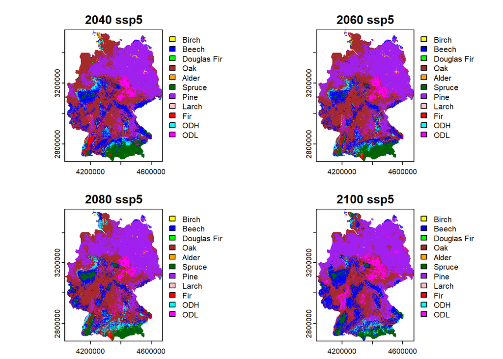

```r
# Plot with proper legend and species names for ssp5
plot(raster_stack_preds[[c(2,4,6,8)]],
     main = titles_ssp5,
     col = species_colors)
```

#### Difference maps SSP2

Now we want to visualize the difference between the time steps. Which tree species has moved to new habitats?

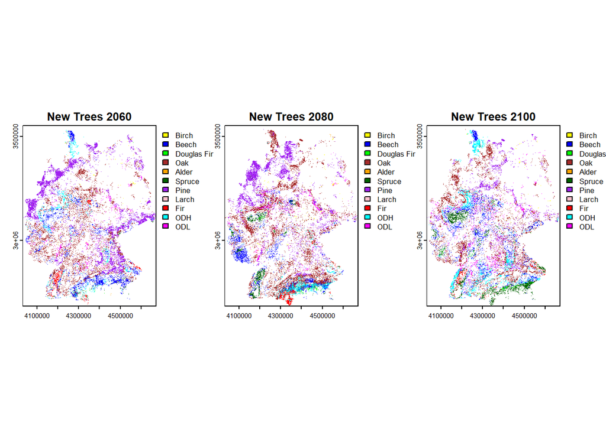

```r
# Calculate differences
diff_2040_2060_ssp2 = raster_stack_preds[[3]] - raster_stack_preds[[1]]
diff_2060_2080_ssp2 = raster_stack_preds[[5]] - raster_stack_preds[[3]]
diff_2080_2100_ssp2 = raster_stack_preds[[7]] - raster_stack_preds[[5]]

# Reclassify: 0 becomes NA, all other values become 1
diff_2040_2060_ssp2 = lapp(diff_2040_2060_ssp2, function(x) ifelse(x == 0, NA, 1))
diff_2060_2080_ssp2 = lapp(diff_2060_2080_ssp2, function(x) ifelse(x == 0, NA, 1))
diff_2080_2100_ssp2 = lapp(diff_2080_2100_ssp2, function(x) ifelse(x == 0, NA, 1))

# Map new trees to species
new_trees_2060_ssp2 = as.factor(diff_2040_2060_ssp2 * raster_stack_preds[[3]])
new_trees_2080_ssp2 = as.factor(diff_2060_2080_ssp2 * raster_stack_preds[[5]])
new_trees_2100_ssp2 = as.factor(diff_2080_2100_ssp2 * raster_stack_preds[[7]])


# Add species labels to the raster factor levels
add_species_labels <- function(raster_layer) {
  levels(raster_layer) <- data.frame(
    ID = as.numeric(names(species_labels)),
    Class = species_labels
  )
  return(raster_layer)
}

# Apply the species labels to the calculated rasters
new_trees_2060_ssp2 <- add_species_labels(as.factor(diff_2040_2060_ssp2 * raster_stack_preds[[3]]))
new_trees_2080_ssp2 <- add_species_labels(as.factor(diff_2060_2080_ssp2 * raster_stack_preds[[5]]))
new_trees_2100_ssp2 <- add_species_labels(as.factor(diff_2080_2100_ssp2 * raster_stack_preds[[7]]))

# Plot new trees with species names in the legend
par(mfrow = c(1, 3))  # 1 row, 3 columns
plot(new_trees_2060_ssp2, main = "New Trees 2060", col = species_colors)
plot(new_trees_2080_ssp2, main = "New Trees 2080", col = species_colors)
plot(new_trees_2100_ssp2, main = "New Trees 2100", col = species_colors)
```

#### Difference maps ssp5

Can you please make the same analysis for ssp5?

```r
# Calculating differences
```

#### Analyzing a specific tree species

Lets see how a specific tree species has performed over time.

For the following analysis, the whole area of Germany is see as potential forest, it is not restricted to the forested areas of today.

[figure not shown]

```r
# set multople windows
par(mfrow = c(3,4))

for(i in 1:length(species_labels)){

  species = i
  calc_area = function(raster, species) {
    sum(values(raster) == species, na.rm = TRUE) * res(raster)[1] * res(raster)[2]
  }

  area_species = c(
    calc_area(raster_stack_preds[[c(2)]], species), #SSP5 2040, 2 = Birch
    calc_area(raster_stack_preds[[c(4)]], species), #SSP5 2060, 2 = Birch
    calc_area(raster_stack_preds[[c(6)]], species), #SSP5 2080, 2 = Birch
    calc_area(raster_stack_preds[[c(8)]], species)  #SSP5 2100, 2 = Birch
  )

  area_species = area_species/1000000 #m² to km²
  years = c(2040, 2060, 2080, 2100)

    # Plotting timeseries
    plot(years, area_species, type = "b", col = "darkgreen", pch = 16,
       xlab = "Year", ylab = "Area (km²)", main = species_labels[i])
}
```

#### Histograms of tree species distribution over time

Let us now make a somewhat more comprehensive analysis. We want to inspect the proportions of tree species over time.

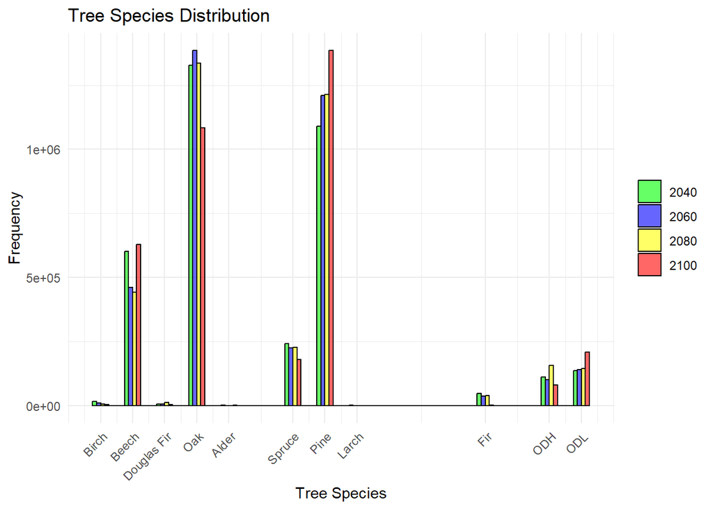

```r
# timesteps 2040, 2060, 2080, and 2100
r1 = values(raster_stack_preds[[2]])  # For 2040
r2 = values(raster_stack_preds[[4]])  # For 2060
r3 = values(raster_stack_preds[[6]])  # For 2080
r4 = values(raster_stack_preds[[8]])  # For 2100

# Sample 10% of the data for faster plotting
sample_size = 0.1  # 10% sample
r1_sample = sample(r1, size = length(r1) * sample_size, replace = FALSE)
r2_sample = sample(r2, size = length(r2) * sample_size, replace = FALSE)
r3_sample = sample(r3, size = length(r3) * sample_size, replace = FALSE)
r4_sample = sample(r4, size = length(r4) * sample_size, replace = FALSE)

# Create a data frame with sampled values and corresponding years
df = data.frame(
  value = c(r1_sample, r2_sample, r3_sample, r4_sample),
  year = factor(rep(c(2040, 2060, 2080, 2100),
                   times = c(length(r1_sample), length(r2_sample), length(r3_sample), length(r4_sample))),
                levels = c(2040, 2060, 2080, 2100))
)



# Update ggplot with species names on the x-axis
ggplot(df, aes(x = value, fill = year)) +
  geom_histogram(binwidth = 0.5, position = "dodge", alpha = 0.6, color = "black") +
  labs(title = "Tree Species Distribution", x = "Tree Species", y = "Frequency") +
  scale_fill_manual(values = c("green", "blue", "yellow", "red")) +
  scale_x_continuous(
    breaks = as.numeric(names(species_labels)),  # Numeric breaks
    labels = species_labels  # Custom labels
  ) +
  theme_minimal() +
  theme(
    legend.title = element_blank(),  # Remove legend title
    axis.text.x = element_text(angle = 45, hjust = 1)  # Rotate x-axis labels for better readability
  )
```

#### Animation of tree species distribution

- A GIF can show how tree species distributions evolve over time, making it easier to observe trends, such as shifts in habitat ranges due to climate change.
- GIFs are simple and engaging, making complex data more accessible to broader audiences, including policymakers, stakeholders, and the general public.

```r
saveGIF({

  plot(raster_stack_preds[[c(1)]], main = titles_ssp2[1], col = species_colors)
  plot(raster_stack_preds[[c(3)]], main = titles_ssp2[2], col = species_colors)
  plot(raster_stack_preds[[c(5)]], main = titles_ssp2[3], col = species_colors)
  plot(raster_stack_preds[[c(7)]], main = titles_ssp2[4], col = species_colors)

}, movie.name = "tree_species_animation.gif")
```

```
[1] TRUE
```

```r
saveGIF({

  plot(raster_stack_preds[[c(2)]], main = titles_ssp5[1], col = species_colors)
  plot(raster_stack_preds[[c(4)]], main = titles_ssp5[2], col = species_colors)
  plot(raster_stack_preds[[c(6)]], main = titles_ssp5[3], col = species_colors)
  plot(raster_stack_preds[[c(8)]], main = titles_ssp5[4], col = species_colors)

}, movie.name = "tree_species_animation.gif")
```

```
[1] TRUE
```

#### Interactive map of tree species distribution using Leaflet

Leaflet allows users to explore the data interactively. They can zoom in, pan around, and focus on specific regions of interest.

```r
template = rast(ext(raster_stack_preds[[1]]), crs = crs(raster_stack_preds[[1]]), resolution = 1000)  # 1000-meter resolution

# Resample raster to match the template's resolution
resampled_raster = resample(raster_stack_preds[[8]], template)

# Add the raster to the leaflet map
leaflet() %>%
  addTiles() %>%
  addRasterImage(resampled_raster, colors = species_colors, opacity = 0.8) %>%
  addLegend(colors = species_colors,
            values = species_labels,
            title = "Tree Species 2100",
            labels = species_labels)
```

[interactive chart not shown]